# Julia packages

earth2studio returns `xarray` objects from data sources and IO backends. [DimensionalData.jl](https://rafaqz.github.io/DimensionalData.jl/) converts `xarray.DataArray` and `xarray.Dataset` to `DimArray` and `DimStack` without copying the data, and its Makie extension plots the result with labelled axes. The PythonCall integration activates automatically when both packages are loaded.

```julia
using Earth2Studio
using Dates
using DimensionalData
using CairoMakie
using PythonCall: pyimport, pyconvert, pylist, pydict
```

## xarray to DimensionalData

Fetch 2 m temperature and 10 m zonal wind at five times from ARCO ERA5:

```julia
ds = Earth2Studio.data.ARCO(verbose=false)
t0 = DateTime(2023, 6, 15)
da = ds(pylist(t0 .+ Hour.(0:6:24)), pylist(["t2m", "u10m"]))
da.dims
```

```
Python: ('time', 'variable', 'lat', 'lon')
```

`pyconvert(DimArray, da)` does the conversion, with one preparation step. DimensionalData reads each coordinate as an attribute of the DataArray, and `DataArray.variable` is an xarray property that returns the array’s underlying `Variable` rather than the coordinate named `variable`. Rename that dimension before converting:

```julia
A = pyconvert(DimArray, da.rename(variable="field"))
```

```
┌ 1440×721×2×5 DimArray{Float64, 4} ┐
├───────────────────────────────────┴──────────────────────────────────── dims ┐
  ↓ lon Sampled{Float64} [0.0, …, 359.75] ForwardOrdered Irregular Points,
  → lat Sampled{Float64} [90.0, …, -90.0] ReverseOrdered Irregular Points,
  ↗ field Categorical{PythonCall.Utils.StaticString{UInt32, 4}} ["t2m", "u10m"] ForwardOrdered,
  ⬔ time Sampled{PythonCall.NumpyDates.InlineDateTime64{PythonCall.NumpyDates.MICROSECONDS}} [PythonCall.NumpyDates.InlineDateTime64{PythonCall.NumpyDates.MICROSECONDS}("2023-06-15T00:00:00"), …, PythonCall.NumpyDates.InlineDateTime64{PythonCall.NumpyDates.MICROSECONDS}("2023-06-16T00:00:00")] Forwa…
└──────────────────────────────────────────────────────────────────────────────┘
[:, :, 1, 1]
   ↓ →    90.0     89.75    89.5    …  -89.25   -89.5    -89.75   -90.0
   0.0   273.981  273.941  273.922     224.077  224.429  224.98   224.723
   0.25  273.981  273.941  273.921     224.079  224.43   224.985  224.723
   0.5   273.981  273.941  273.921     224.08   224.434  224.989  224.723
   ⋮                                ⋱                      ⋮
 359.25  273.981  273.941  273.922     224.079  224.424  224.977  224.723
 359.5   273.981  273.941  273.922     224.079  224.427  224.979  224.723
 359.75  273.981  273.941  273.922  …  224.077  224.429  224.98   224.723
```

Two things changed. The dimensions are reversed, `(lon, lat, field, time)` in place of `(time, variable, lat, lon)`, because Python stores arrays row-major and Julia column-major. Reversing keeps the fast axis the same in both languages, so no data moves. And the data is shared: `parent(A)` is a `PyArray` viewing the numpy buffer. Pass `copy=true` to get a plain `Array`.

```julia
typeof(parent(A))
```

```
PythonCall.PyArray{Float64, 4, true, true, Float64}
```

The `time` lookup holds numpy `datetime64` values. Replace it with `DateTime` so that selectors take Julia dates and Makie can label the axis:

```julia
A = set(A, :time => pyconvert(Vector{DateTime}, da.time.values))
lookup(A, :time)
```

```
Sampled{Dates.DateTime} ForwardOrdered Irregular DimensionalData.Dimensions.Lookups.Points
wrapping: 5-element Vector{DateTime}:
 2023-06-15T00:00:00
 2023-06-15T06:00:00
 2023-06-15T12:00:00
 2023-06-15T18:00:00
 2023-06-16T00:00:00
```

Selectors index by coordinate value. `At` matches exactly and `Near` picks the closest point:

```julia
raleigh = A[field=At("t2m"), lat=Near(35.8), lon=Near(281.3)]
```

```
┌ 5-element DimArray{Float64, 1} ┐
├────────────────────────────────┴─────────────────────────────────────── dims ┐
  ↓ time Sampled{Dates.DateTime} [Dates.DateTime("2023-06-15T00:00:00"), …, Dates.DateTime("2023-06-16T00:00:00")] ForwardOrdered Irregular Points
└──────────────────────────────────────────────────────────────────────────────┘
 2023-06-15T00:00:00  300.231
 2023-06-15T06:00:00  294.853
 2023-06-15T12:00:00  294.244
 2023-06-15T18:00:00  302.782
 2023-06-16T00:00:00  300.388
```

## Plotting with Makie

DimensionalData’s Makie extension reads axis labels, ticks, and the title from the dimensions, so a `DimArray` plots without extracting coordinate vectors. The title lists the coordinates that were selected away.

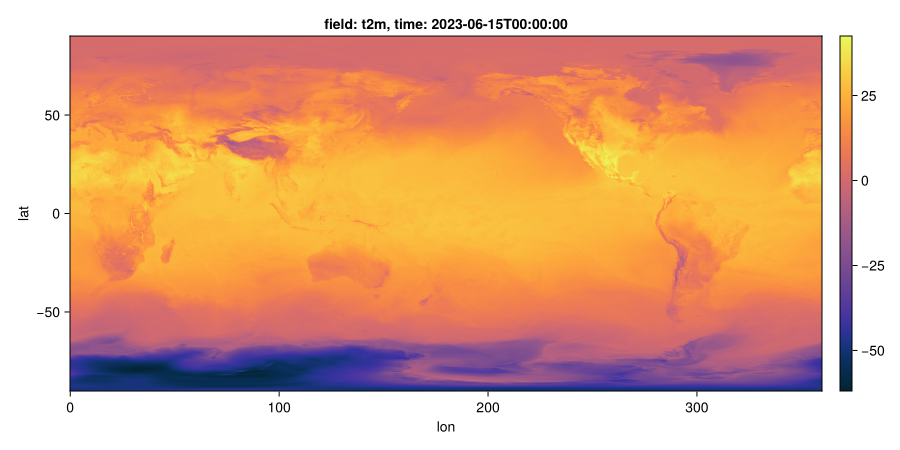

```julia
fig = Figure(size=(900, 450))
heatmap(fig[1, 1], A[field=At("t2m"), time=At(t0)] .- 273.15; colormap=:thermal)
fig
```

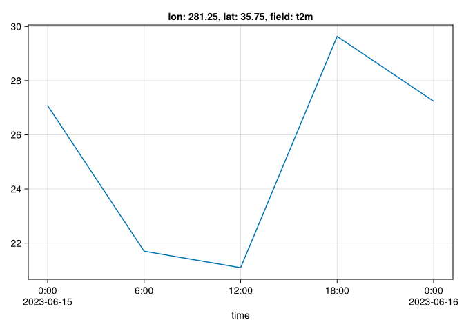

```julia
lines(raleigh .- 273.15; axislegend=false)
```

## Datasets to DimStack

`XarrayBackend` stores a forecast as an `xarray.Dataset` with one data variable per field. `pyconvert(DimStack, ...)` converts each variable to a layer that shares the same dimensions. The setup below is the Persistence forecast from the Forecasting tutorial.

```julia
np = pyimport("numpy")
grid = pydict("lat" => np.linspace(90, -90, 721), "lon" => np.linspace(0, 359.75, 1440))
model = Earth2Studio.models.px.Persistence("t2m", grid)
io = Earth2Studio.io.XarrayBackend()
Earth2Studio.run.deterministic([t0], 4, model, ds, io; verbose=false)
S = pyconvert(DimStack, io.root)
```

```
┌ 1440×721×5×1 DimStack ┐
├───────────────────────┴──────────────────────────────────────────────── dims ┐
  ↓ lon Sampled{Float64} [0.0, …, 359.75] ForwardOrdered Irregular Points,
  → lat Sampled{Float64} [90.0, …, -90.0] ReverseOrdered Irregular Points,
  ↗ lead_time Sampled{PythonCall.NumpyDates.InlineTimeDelta64{PythonCall.NumpyDates.SECONDS}} [PythonCall.NumpyDates.InlineTimeDelta64{PythonCall.NumpyDates.SECONDS}(0), …, PythonCall.NumpyDates.InlineTimeDelta64{PythonCall.NumpyDates.SECONDS}(86400)] ForwardOrdered Irregular Points,
  ⬔ time Sampled{PythonCall.NumpyDates.InlineDateTime64{PythonCall.NumpyDates.NANOSECONDS}} [PythonCall.NumpyDates.InlineDateTime64{PythonCall.NumpyDates.NANOSECONDS}("2023-06-15T00:00:00")] ForwardOrdered Irregular Points
├────────────────────────────────────────────────────────────────────── layers ┤
  :t2m eltype: Float64 dims: lon, lat, lead_time, time size: 1440×721×5×1
└──────────────────────────────────────────────────────────────────────────────┘
```

The `lead_time` lookup holds numpy `timedelta64` values, which convert to `Hour` the same way `time` converts to `DateTime`. Layers are accessed by name and support the same selectors:

```julia
S = set(S, :time => pyconvert(Vector{DateTime}, io.root.time.values),
           :lead_time => pyconvert(Vector{Hour}, io.root.lead_time.values))
S[:t2m][lead_time=At(Hour(12)), lat=Near(35.8), lon=Near(281.3)]
```

```
┌ 1-element DimArray{Float64, 1} t2m ┐
├────────────────────────────────────┴─────────────────────────────────── dims ┐
  ↓ time Sampled{Dates.DateTime} [Dates.DateTime("2023-06-15T00:00:00")] ForwardOrdered Irregular Points
└──────────────────────────────────────────────────────────────────────────────┘
 2023-06-15T00:00:00  300.231
```

## Other packages

[Rasters.jl](https://rafaqz.github.io/Rasters.jl/) and [YAXArrays.jl](https://juliadatacubes.github.io/YAXArrays.jl/) build on DimensionalData, so a converted `DimArray` is their input type once its `lon` and `lat` dimensions are renamed to `X` and `Y`. For a Python-free path, `NetCDF4Backend` writes a file that [NCDatasets.jl](https://juliageo.org/NCDatasets.jl/) and Rasters.jl open directly.